# Final Project - Written Report

Author

Kaatje Matthews, Alex Tran, Jena Weitzman, Alie Hall

```r
# Load packages

library(tidyverse)
library(rlang)
library(gganimate)
library(gifski)
library(gridExtra)
library(patchwork)
gdp <- read_csv(file = "gdp_pcap.csv")
energy <- read_csv(file = "energy_use_per_person.csv")

# 1st helper function

data_cleaning <- function(og_data, new_data, variables, names, values){

  # Select variables of interest + pivot longer

  new_data <- og_data |>
    select(country, {{ variables }}) |>
    pivot_longer(cols = {{ variables }},
                 names_to = {{ names }},
                 values_to = {{ values }})

  return(new_data)

}

# 2nd helper function

k_to_val <- function(data, variable){

  # Turn values of _k into integers

  data <- data |>
    mutate(across(.cols = {{ variable }},
                  .fns = ~ ifelse(str_detect(string = .x,
                                             pattern = "k|K"),
                                  1000*as.numeric(str_remove_all(string = .x,
                                                                 pattern = "k|K")),
                                  as.numeric(.x)
                                  )))

  return(data)

}

# Transform energy dataset into energy_long

energy_long <- data_cleaning(og_data = energy,
                             new_data = energy_long,
                             variables = `1975`:`2013`,
                             names = "year",
                             values = "energy_use")

# Transform _k values

energy_long <- k_to_val(data = energy_long,
                        variable = "energy_use")

# Transform gdp dataset into gdp_long

gdp_long <- data_cleaning(og_data = gdp,
                          new_data = gdp_long,
                          variables = `1975`:`2013`,
                          names = "year",
                          values = "gdp")

# Transform _k values

gdp_long <- k_to_val(data = gdp_long,
                          variable = "gdp")

# Join both datasets together

final_data <- inner_join(energy_long,
                         gdp_long,
                         by = join_by(country, year))
```

## Introduction

#### Gapminder: GDP Per Capita Vs. Energy Use Per Person

Gapminder is an independent Swedish foundation that collects reliable data on global topics in order to systematically combat “devastating ignorance with a fact-based worldview everyone can understand.” They do this by combining data from multiple reliable sources in order to give the everyday person a more accurate view of what the world is like.

More information about Gapminder can be found [here](https://www.gapminder.org/).

In particular, our group decided to investigate the relationship between GDP Per Capita, a measure of purchasing power, and Energy Use Per Person.

#### Data set #1: GDP Per Capita

The data set `gdp_pcap.csv` records the GDP per capita for various countries in a given year, or the value of everything produced in a country each year, divided by the country’s population.This particular data sets records the GDP per capita of 195 countries in each year from 1800 to 2023, as well as the predicted GDP per capita in each year from 2024 until 2100. Gapminder labels the units of measurement for GDP per capita as constant PPP (Purchasing Power Parity) dollars. There are 195 rows in this data set, each one representing a different country, and 302 columns, each one representing a different year.

#### Data set #2: Energy Use per Person

The dataset `energy_use_per_person.csv` records the energy use per person in various countries, for each year from 1960 to 2013. In this case, energy use per person is referring to the use of primary energy before transformation to other end-use fuels. Gapminder labels the units of measurement for energy use per person as kg of oil equivalent per capita. This data set has 173 rows, with each row representing a different country, and 57 columns, with each column representing a different year.

#### Hypothesized Relationship

We are setting our explanatory variable to be GDP per capita, and our response variable as energy use per person. We believe that the relationship between GDP and energy use per Person will be positively correlated, meaning that a larger GDP for a country will be associated with more energy use per person. In addition, through the years, with a rise in accessibility of sustainable energy, we believe that the overall trend of energy use per person will be positive. Furthermore, the rise of globalization has increased GDPs over time, leading to another positive trend.

#### Data Cleaning Process and Decision-Making

Since each year in both of the data sets was its own separate column, making the data very difficult to analyze, we decided to pivot the data from wide to long format. This way, we could see each year as its own observation, rather than the difficult-to-read columns that they were in before. We also decided that in the GDP per capita data set, we wanted to get rid of any years that were not consistent with the years recorded in the energy use per person data set, so we made the decision to delete any data recorded before 1975, as well as anything after 2013. Additionally, the observations in the GDP per capita data set were not consistent. Some of the observations were number values, and some of them had abbreviations using character variables. For example, some of the observations said “4k” to represent a GDP of $4,000, so in order to make the data consistent for the purpose of analyzing, we used a function to remove all instances of the letter “k” and multiply the value by 1,000 to represent the “k” numerically. After pivoting and cleaning both data sets, we joined the them using an inner join so that any countries with no data for either variable in a specific year would not be included. This final data set contains 6630 observations (including 170 unique countries) and 4 variables: Country, Year, GDP, and energy use.

## Data Visualizations

#### Visualization 1: Relationship over Time (GIF)

To explore the relationship between the two, we decided to create a GIF comparing GDP per capita and energy use across the different years of interest. This helps to visualize the relationship between the two, of course, but also how that relationship changes over the years, if it changes at all.

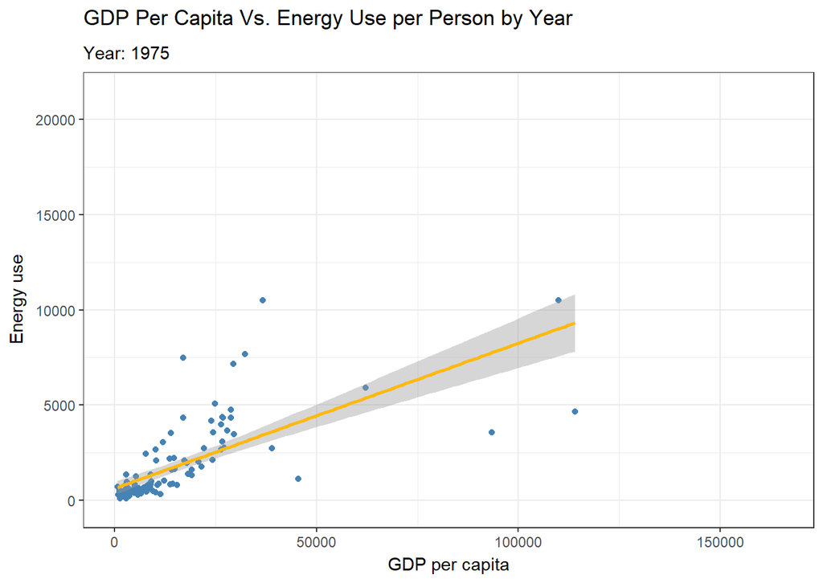

```r
# Code to make GIF animation

gif <- final_data |>
  mutate(year = as.integer(year)) |>
  ggplot(aes(x=gdp,
             y=energy_use)) +
  geom_point(col = "steelblue") +
  geom_smooth(method = "lm",
              col = "darkgoldenrod1") +
  labs(title = 'GDP Per Capita Vs. Energy Use per Person by Year',
       subtitle = 'Year: {frame_time}',
       x = 'GDP per capita',
       y = 'Energy use') +
  transition_time(year) +
  ease_aes('linear') +
  theme_bw()

animate(gif, renderer = gifski_renderer(), fps = 7)
```

The GIF shows that the relationship between GDP per capita and energy use per person remains similar over the years: a strong, positive, linear relationship of energy use increasing as GDP increases.

#### Visualization 2: Scatterplot

Because the relationship between GDP and energy use was similar over the years, we decided to average the data points over years for each country and create a scatter plot with average GDP in the x-axis and average energy use in the y-axis. We will be using this averaged data set moving forward.

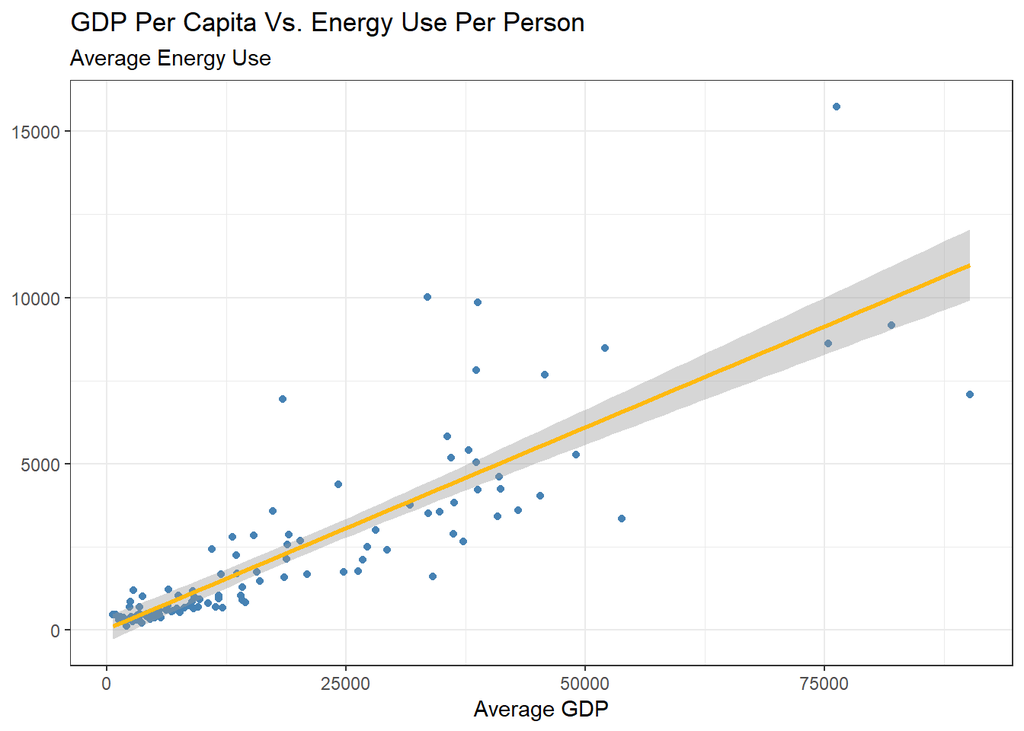

```r
# Average values across the years

averaged_data <- final_data |>
  group_by(country) |>
  summarise(avg_energy = mean(energy_use),
            avg_gdp = mean(gdp))

averaged_data |>
  ggplot(aes(x=avg_gdp,
             y=avg_energy)) +
  geom_point(col = "steelblue") +
  geom_smooth(method = "lm",
              col = "darkgoldenrod1") +
  labs(
    title = "GDP Per Capita Vs. Energy Use Per Person",
    subtitle = "Average Energy Use",
    x = "Average GDP",
    y = NULL
  ) +
  theme_bw()
```

Our linear regression model calculated by R reveals a strong, positive, and linear relationship between average GDP per capita and energy use per person, insinuating that, as GDP increases, energy use increases and that countries with a greater GDP may have a higher energy use per person. Visually, there are a couple unusual points. The point that is the highest up and to the right, at which average GDP per capita is just above 75000, and average energy use per person is about 15000, is quite far from the line of best fit. Another unusual point is the point at which average GDP per capita is about 35000, and average energy use is 10000.

## Linear Regression

#### GDP Per Capita Vs. Energy Use Per Person

We decided to use linear regression to model the relationship between GDP per capita and energy use per person. In our linear regression, we have defined GDP per capita as our explanatory variable, and energy use per person as our response variable.

#### Regression Model

We will fit a linear regression model in order to derive the estimated regression equation.

```r
#Regression Model
energy_gdp_model <- lm(avg_energy ~ avg_gdp,
                       data = averaged_data)
```

#### Linear Regression Conditions

In order to apply an accurate linear regression model to our data, we must make sure that our data satisfies the four conditions of linear regression. Our first condition, linearity, is met, in this case, because the relationship between the explanatory and response variable is proportional to one another. Our second condition, independence, is met because the result of GDP per capita each year is independent of one another for each recorded observation, and energy use per person each year is independent of one another for each recorded observation. Our third condition, normality, is met because for both GDP per capita and energy use per person have more than 30 observations, by the Central Limit Theorem. Lastly, our fourth condition of equal variance is not necessarily met, because our residual plot “fans out”. However, most of the data points that result in this fanning are outliers as discussed earlier and the majority of these data are within the range where equal variances are met. Therefore, we feel comfortable continuing the analysis. (Residual plot shown below).

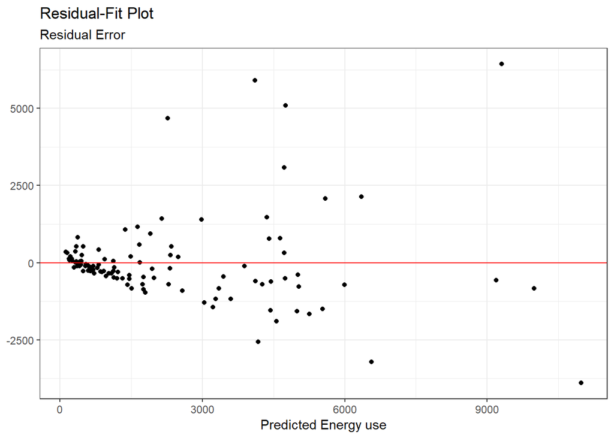

```r
# Residual Plot
energy_gdp_model |>
  broom::augment() |>
  ggplot(aes(x=.fitted,
                     y=.resid)) +
  geom_point() +
  geom_hline(yintercept = 0,
             color = "red") +
  labs(x="Predicted Energy use",
       y=NULL,
       subtitle="Residual Error",
       title="Residual-Fit Plot") +
  theme_bw()
```

```r
#Regression terms
broom::tidy(energy_gdp_model) |>
   knitr::kable("html")
```

| term | estimate | std.error | statistic | p.value |
| --- | --- | --- | --- | --- |
| (Intercept) | 34.8143627 | 194.1173524 | 0.179347 | 0.8580013 |
| avg_gdp | 0.1214221 | 0.0073159 | 16.596965 | 0.0000000 |

From our regression model, we can come up with an linear equation to model the predicted values of energy use with GDP per capita inputs.

Equation: Predicted Average Energy Use per Person = 0.121(Average GDP) + 34.814

Put more simply, our linear regression model tells us that for every 1 unit increase in constant PPP dollars (GDP), the predicted energy use per person will increase by 0.121 kg of oil equivalent per capita (energy use). Our intercept tells us that a country with a GDP of 0 constant PPP dollars would be expected to have energy use of 34.814 kg of oil equivalent per capita per person.

#### Model Fit

To test how well this linear regression model fits the data, we will look at the amount of variability that we can account for with our model.

```r
# Display variances and calculate proportion of var

energy_gdp_model |>
  broom::augment() |>
  summarize(variance_energy = var(avg_energy),
            variance_fitted = var(.fitted),
            variance_residual = var(.resid)) |>
  mutate(prop = variance_fitted/variance_energy) |>
  knitr::kable("html")
```

| variance_energy | variance_fitted | variance_residual | prop |
| --- | --- | --- | --- |
| 7191502 | 5166040 | 2025462 | 0.7183534 |

Based on the proportion of variability that can be accounted for by our model, ~71.84% of the total variability can be attributed to our model, which is generally a good sign that our model fits well.

## Simulation

#### Creating Simulated Data from Linear Model

Next, we will create simulated data from our linear model in order to compare how similar/different our observed data is from our simulated data as another measure of how well our linear model fits. To do this, we will generate predictions from our linear model and use those predictions to simulate observations.

```r
# Set seed for consistent output
set.seed(1234)

# Create simulated data
simulated_data <- averaged_data |>

  # Remove NA values
  filter(!is.na(avg_energy)) |>

  # Mutate (add column) with predict to obtain simulated
  mutate(predicted = predict(energy_gdp_model)) |>
  mutate(simulated = predicted + rnorm(length(predicted),
                                       mean = 0,
                                       sd = sigma(energy_gdp_model))
         )
```

#### Visualize Simulated Data Vs. Observed Data

To visually compare the two data sets (simulated and observed), we will create two scatterplots where both scatterplots will have GDP as their x-axes but one scatterplot will have its y-axis be simulated while the other is observed.

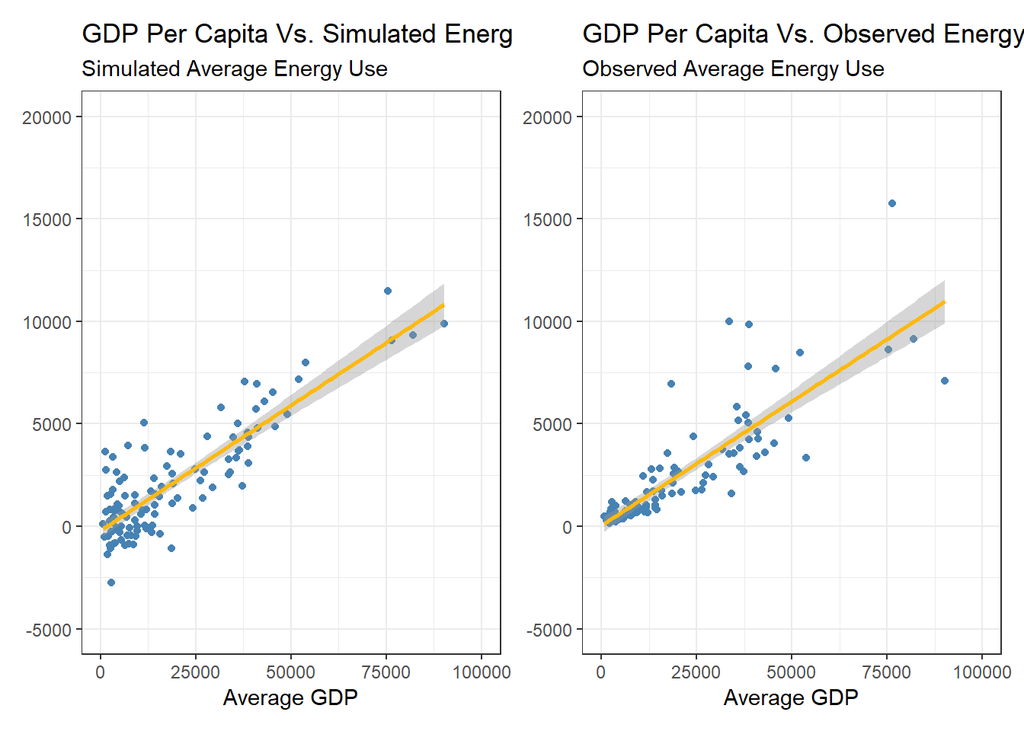

```r
# 2 scatterplots: gdp vs simulated and gdp vs observed

# 1st scatterplot: gdp vs simulated

plot1 <- ggplot(simulated_data,
       mapping = aes(
         x = avg_gdp,
         y = simulated
       )) +
  geom_point(col = "steelblue") +
  geom_smooth(method = "lm",
              col = "darkgoldenrod1") +
  labs(
    title = "GDP Per Capita Vs. Simulated Energy Use Per Person",
    subtitle = "Simulated Average Energy Use",
    x = "Average GDP",
    y = NULL
  ) +
  xlim(0, 100000) +
  ylim(-5000, 20000) +
  theme_bw()

# 2nd scatterplot: gdp vs observed

plot2 <- ggplot(simulated_data,
       mapping = aes(
         x = avg_gdp,
         y = avg_energy
       )) +
  geom_point(col = "steelblue") +
  geom_smooth(method = "lm",
              col = "darkgoldenrod1") +
  labs(
    title = "GDP Per Capita Vs. Observed Energy Use Per Person",
    subtitle = "Observed Average Energy Use",
    x = "Average GDP",
    y = NULL
  ) +
  xlim(0, 100000) +
  ylim(-5000, 20000) +
  theme_bw()

# Patch the two plots together

plot1 + plot2 + plot_layout(nrow = 1)
```

#### Generating Multiple Predictive Checks

To further analyze how well our regression model describes the relationship between GDP and energy use, we have generated 10,000 simulated datasets that we would expect to see if our regression model accurately described our relationship of interest. From there, we will then regress the observed data against each simulated data set and keep the R^2 value from each regression.

```r
new_df <- averaged_data |>
  filter(!is.na(avg_energy))

# Create function to accomplish one simulation
sim_energy_data <- function(observed, lm){
  predicted <- predict({{lm}})
  simulated <- predicted + rnorm(length(predicted),
                                       mean = 0,
                                       sd = sigma({{lm}}))

  simulated_model <- lm({{observed}} ~ simulated)
  r_squared_val <- summary(simulated_model)$r.squared

  return(r_squared_val)

}

# Use map_df to do it 1000 times
r_squared_dist <- map_df(1:10000,
                         ~tibble(r2 = sim_energy_data(observed = new_df$avg_energy,
                                                      energy_gdp_model)))
```

To visualize the R^2 values, we will create a histogram of the R^2 values to see how well our model describes our relationship of interest.

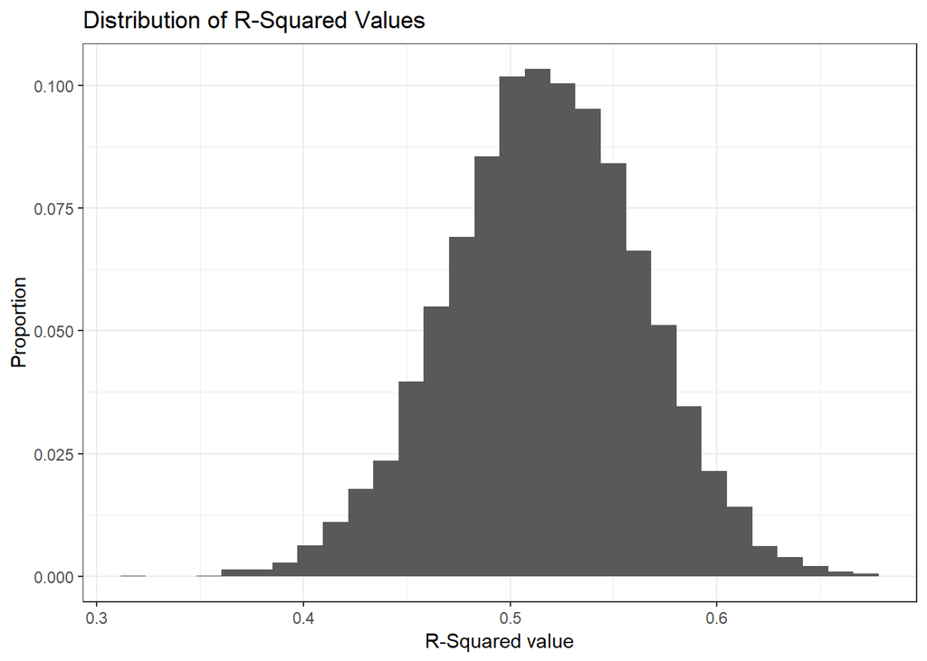

```r
# Plot to distribute R^2 values as histogram

ggplot(r_squared_dist,
       mapping = aes(
         x = r2
       )) +
  geom_histogram(
    aes(y = after_stat(count/sum(count))
        )
    ) +
  labs(
    x = "R-Squared value",
    y = "Proportion",
    title = "Distribution of R-Squared Values"
  ) +
  theme_bw()
```

The distribution of the R^2 values seems to be approximately normal and symmetric, centered around 0.52. This distribution suggests that the regression model of the simulated data against our observed data seems to have a moderately strong relationship.

## Conclusion

Overall, there is a relationship between Energy Use and GDP per capita. This relationship is positive, strong, and linear, and we believe that this report has proven this relationship.

## Refrences and Citations

https://www.gapminder.org/data/